# Analysis of iSNVs called using iVar from spkied in, invivo, invitro and field samples.

gkarthik

November 4, 2018

We first assess the number of true positives and false positives from spiked in sample with Zika virus RNA from isolates PRVABC59 (Puerto Rico 2015, Genbank KX087101, ‘virus #1’) and FSS13025 (Cambodia 2010, Genbank KU955593, ‘virus #2’). Virus #2 was spiked in at 10%. The sites with true iSNVs(true positives) and sites that were expected to be constant were determined using gold standard metagenomic sequencing. These positions are documented in ZIKV-intrahost_True-False-Remove.csv.

iSNVs were called for each of three technical replicates PZ34(A), PZ35(B) and PZ36(C) separately and then filtered by looking at common variants using the command “ivar filtervariants”.

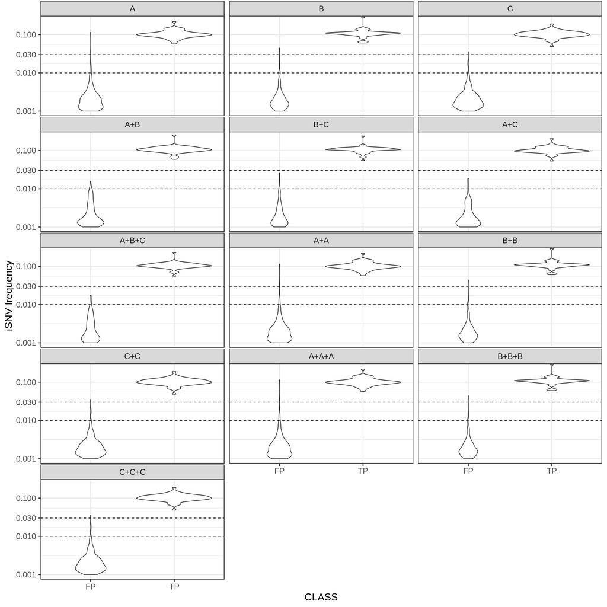

```r
library(ggplot2)
library(dplyr)
library(reshape2)

## Generated in a specific order for figure. If order isn't important just use list.files("masked_variants/mix10", full.names=TRUE).
prefixes <- c("PZ34", "PZ35", "PZ36", "PZ34_35", "PZ35_36", "PZ34_36", "PZ34_35_36", "PZ34_34", "PZ35_35", "PZ36_36", "PZ34_34_34", "PZ35_35_35", "PZ36_36_36")

labels <- c("A", "B", "C", "A+B", "B+C", "A+C", "A+B+C", "A+A", "B+B", "C+C", "A+A+A", "B+B+B", "C+C+C")

true_variants <- read.csv("./ZIKV-intrahost_True-False-Remove.csv", header=TRUE)

for(i in c(1:length(prefixes))){
    r <- read.table(paste("./masked_variants/mix10/", prefixes[i], ".tsv", sep=""), header=TRUE, sep = "\t")

    alt_freq <- colnames(r)[grepl("ALT_FREQ", colnames(r))]
    if(length(alt_freq)>1){
        r[,"ALT_FREQ"] <- rowMeans(r[,alt_freq]) #In case of filtered iSNV reports, take average frequency since no filtering is done.
    } else {
        r[,"ALT_FREQ"] <- r[,alt_freq]
    }
    alt_freq <- "ALT_FREQ"

    r[,"REPLICATE"] <- labels[i]
    r <- r[(r[,alt_freq] >= 0.001) & (r$REF != "N"), ]
    r <- r[order(r$POS, -abs(r[,alt_freq]) ), ]
    r <- r[ !duplicated(r$POS), ]

    tp <- r[r[,"POS"] %in% true_variants[true_variants[,"True.False.Remove"]==TRUE,"Position"],]
    tp[,"CLASS"] <- "TP"

    fp <- r[r[,"POS"] %in% true_variants[true_variants[,"True.False.Remove"]==FALSE,"Position"],]
    fp[,"CLASS"] <- "FP"

    if(i==1){
        res <- rbind(tp[,c("REPLICATE", "CLASS", alt_freq)], fp[,c("REPLICATE", "CLASS", alt_freq)])
    } else {
        res <- rbind(res, tp[,c("REPLICATE", "CLASS", alt_freq)], fp[,c("REPLICATE", "CLASS", alt_freq)])
    }
}

res$REPLICATE <- factor(res$REPLICATE, levels = labels)

p <- ggplot(res, aes(x=CLASS, y=ALT_FREQ))  +
    stat_summary(fun.y = mean,
               fun.ymin = function(x) mean(x) - sd(x),
               fun.ymax = function(x) mean(x) + sd(x),
               geom = "pointrange") +
    geom_violin() +
    geom_hline(yintercept = c(0.01,0.03), linetype = "dashed") + scale_y_log10(breaks = c(0.001, 0.01, 0.03, 0.1, 1)) +ylab("iSNV frequency") + facet_wrap(~REPLICATE, ncol = 3) + theme_bw(base_size = 18)

p
```

In order to see the effect of using pseudo replicates i.e., the same replicate multiple times instead of technical replicates, let’s look at the correlation between the frequencies found.

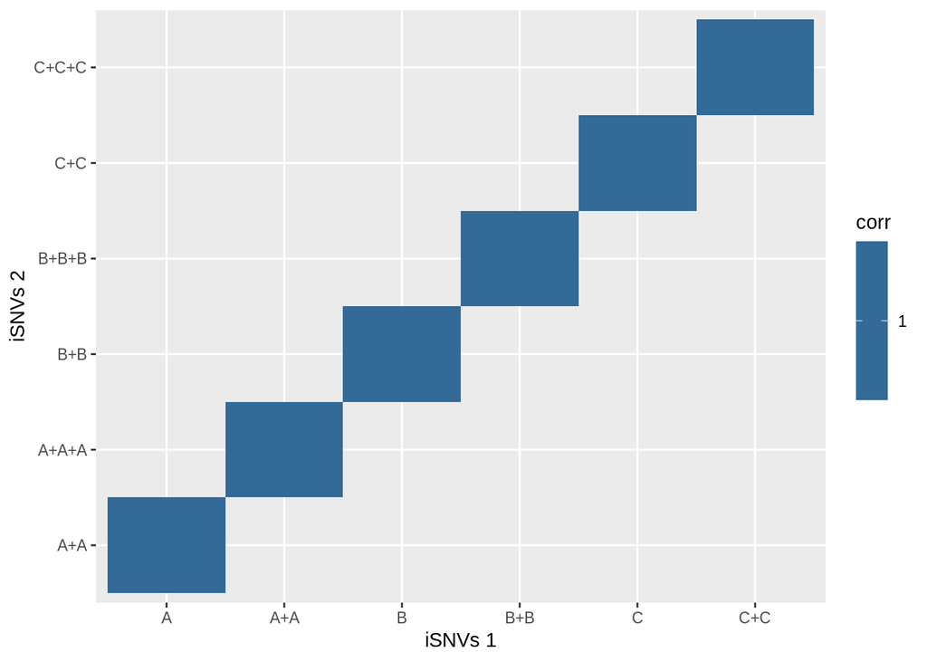

```r
x <- c("A", "A+A", "B", "B+B", "C", "C+C")
y <- c("A+A", "A+A+A", "B+B", "B+B+B", "C+C", "C+C+C")
corr <- sapply(c(1:6), function(i){
    cor.test(res[res$REPLICATE==x[i], "ALT_FREQ"], res[res$REPLICATE==y[i],"ALT_FREQ"])$estimate
})

corr.df <- data.frame(
    x <- x,
    y <- y,
    corr <- corr
)
colnames(corr.df) <- c("x", "y", "corr")

ggplot(corr.df, aes(x=x, y=y, fill=corr)) + geom_tile() + xlab("iSNVs 1") + ylab("iSNVs 2")
```

## Calling iSNVs from invitro, invivo and field samples(Zika and West Nile virus).

Variants called after removing reads from primers with mismtaches are at masked_variants/. These variants were called using pipelines created with [iVar](https://github.com/andersen-lab/com/ivar/), SAMtools, bwa and BEDtools. The pipeline were created using snakemake and are housed in the pipeline/ folder in the iVar repository. The iSNVs were called at a minimum frequency of 3% and a minimum quality of 20.

Below are two functions that will extract the positions and frequencies of alternate alleles from the variants report generated by iVar.

```r
library(plyr)
get_pos_freq_list_replicate_a <- function(filtered_variants, metadata){
    pos_freq.list <- lapply(filtered_variants, function(x){
        field_samples <- read.table(x, sep="\t", header=TRUE)
        field_samples <- field_samples[!grepl("\\+|\\-", field_samples[,"ALT"]),] #Remove insertions and deletions
        rep.a <- cbind(field_samples[, 1:4], field_samples[, grepl("_a", colnames(field_samples))])
        colnames(rep.a) <- sapply(colnames(rep.a), function(x){
            strsplit(x, "_\\.")[[1]][1]
        })
        rep.a <- rep.a[rep.a[,"TOTAL_DP"]>=400,]
        if(nrow(rep.a)>0){
            rep.a[,"REPLICATE"] ="a"
            rep.a[,"FILE"] = strsplit(x, "/")[[1]][7]
            rep.a[,"SPECIES"] <- metadata[metadata$file==strsplit(x, "/")[[1]][4], "species"][1]
        } else {
            rep.a[,"REPLICATE"] = as.character()
            rep.a[,"FILE"] = as.character()
            rep.a[,"SPECIES"] <- as.character()
        }
        return (rep.a[,c("POS", "ALT_FREQ", "REPLICATE", "SPECIES")]);
    });
    return(pos_freq.list);
}

get_pos_freq_list_replicate_b <- function(filtered_variants, metadata){
    pos_freq.list <- lapply(filtered_variants, function(x){
        field_samples <- read.table(x, sep="\t", header=TRUE)
        field_samples <- field_samples[!grepl("\\+|\\-", field_samples[,"ALT"]),] #Remove insertions and deletions
        rep.b <- cbind(field_samples[, 1:4], field_samples[, grepl("_b", colnames(field_samples))])
        colnames(rep.b) <- sapply(colnames(rep.b), function(x){
            strsplit(x, "_\\.")[[1]][1]
        })
        rep.b <- rep.b[rep.b[,"TOTAL_DP"]>=400,]
        if(nrow(rep.b)>0){
            rep.b[,"REPLICATE"] ="b"
            rep.b[,"FILE"] = strsplit(x, "/")[[1]][7]
            rep.b[,"SPECIES"] <- metadata[metadata$file==strsplit(x, "/")[[1]][4], "species"][1]
        } else {
            rep.b[,"REPLICATE"] = as.character()
            rep.b[,"FILE"] = as.character()
            rep.b[,"SPECIES"] <- as.character()
        }
        return (rep.b[,c("POS", "ALT_FREQ", "REPLICATE", "SPECIES")]);
    })
    return(pos_freq.list);
}
```

Let’s now plot the iSNVs found in the intersection of both replicates.

## Field Zika samples

```r
field_zika_path <- "./masked_variants/field_samples_zkv"

filtered_variants <- list.files(field_zika_path, pattern="*.filtered.tsv", full.names=TRUE)

metadata <- data.frame(
    files <- c("ZI-28", "ZI-32", "ZI-33", "ZI-34", "ZI-35", "ZI-47", "ZI-26", "ZI-27"),
    species <- c("Human", "Human", "Aedes", "Aedes", "Aedes", "Aedes", "Human", "Human")
)
colnames(metadata) <- c("file", "species")
metadata$file
```

```
## [1] ZI-28 ZI-32 ZI-33 ZI-34 ZI-35 ZI-47 ZI-26 ZI-27
## Levels: ZI-26 ZI-27 ZI-28 ZI-32 ZI-33 ZI-34 ZI-35 ZI-47
```

```r
metadata$file <- sapply(as.character(metadata$file), function(x){
    paste(x,".filtered.tsv", sep="")
})


## Let's look at the correlation between the iSNVs called form both replicates for all samples
freq.corr <- sapply(filtered_variants, function(x){
    sample <- read.table(x, sep="\t", header=TRUE)
    freq <- cbind(sample[,"POS"], sample[, grepl("ALT_FREQ", colnames(sample))])
    freq.test <- cor.test(freq[,2], freq[,3], method="pearson")
    freq.test$estimate
})

print(freq.corr)
```

```
## ./masked_variants/field_samples_zkv/ZI-26.filtered.tsv.cor
##                                                  0.9877711
## ./masked_variants/field_samples_zkv/ZI-27.filtered.tsv.cor
##                                                  0.8799016
## ./masked_variants/field_samples_zkv/ZI-28.filtered.tsv.cor
##                                                  0.9858001
## ./masked_variants/field_samples_zkv/ZI-32.filtered.tsv.cor
##                                                 -0.0401659
## ./masked_variants/field_samples_zkv/ZI-33.filtered.tsv.cor
##                                                  0.9983822
## ./masked_variants/field_samples_zkv/ZI-34.filtered.tsv.cor
##                                                  0.2437190
## ./masked_variants/field_samples_zkv/ZI-35.filtered.tsv.cor
##                                                  0.9216131
## ./masked_variants/field_samples_zkv/ZI-47.filtered.tsv.cor
##                                                  0.9826250
```

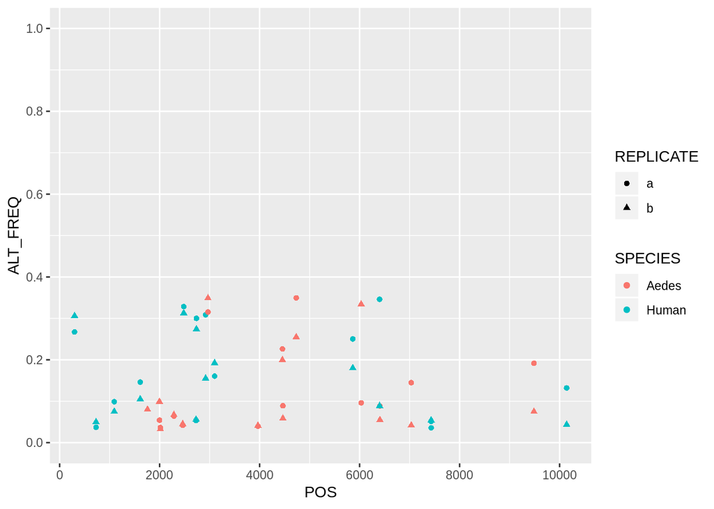

```r
pos_freq.list.a <- get_pos_freq_list_replicate_a(filtered_variants, metadata)
pos_freq.list.b <- get_pos_freq_list_replicate_b(filtered_variants, metadata)


pos_freq <- ldply(pos_freq.list.a)
pos_freq <- rbind(pos_freq, ldply(pos_freq.list.b))

ggplot(pos_freq, aes(x=POS, y=ALT_FREQ, color=SPECIES, shape=REPLICATE)) + geom_point() + scale_x_continuous(breaks = c(0, 2000, 4000, 6000, 8000, 10000)) + scale_y_continuous(limits = c(0, 1), breaks = c(0, 0.2,0.4,0.6,0.8,1))
```

## Field West Nile virus samples

```r
field_wnv_path <- "./masked_variants/field_samples_wnv"

filtered_variants <- list.files(field_wnv_path, pattern="*.filtered.tsv", full.names=TRUE)

metadata <- data.frame(
    files <- c("ZI-55", "ZI-56", "ZI-57", "ZI-58", "ZI-59", "ZI-60", "ZI-61", "ZI-62"),
    species <- c("Culex", "Culex", "Culex", "Culex", "Crow", "Crow", "Crow", "Crow")
)

colnames(metadata) <- c("file", "species")
metadata$file
```

```
## [1] ZI-55 ZI-56 ZI-57 ZI-58 ZI-59 ZI-60 ZI-61 ZI-62
## Levels: ZI-55 ZI-56 ZI-57 ZI-58 ZI-59 ZI-60 ZI-61 ZI-62
```

```r
metadata$file <- sapply(as.character(metadata$file), function(x){
    paste(x,".filtered.tsv", sep="")
})


## Let's look at the correlation between the iSNVs called form both replicates for all samples
freq.corr <- sapply(filtered_variants, function(x){
    sample <- read.table(x, sep="\t", header=TRUE)
    freq <- cbind(sample[,"POS"], sample[, grepl("ALT_FREQ", colnames(sample))])
    freq.test <- cor.test(freq[,2], freq[,3], method="pearson")
    freq.test$estimate
})

print(freq.corr)
```

```
## ./masked_variants/field_samples_wnv/ZI-55.filtered.tsv.cor
##                                                  0.8255764
## ./masked_variants/field_samples_wnv/ZI-56.filtered.tsv.cor
##                                                  0.9771972
## ./masked_variants/field_samples_wnv/ZI-57.filtered.tsv.cor
##                                                  0.9884330
## ./masked_variants/field_samples_wnv/ZI-58.filtered.tsv.cor
##                                                  0.3526524
## ./masked_variants/field_samples_wnv/ZI-59.filtered.tsv.cor
##                                                  0.9978326
## ./masked_variants/field_samples_wnv/ZI-60.filtered.tsv.cor
##                                                  0.9984815
## ./masked_variants/field_samples_wnv/ZI-61.filtered.tsv.cor
##                                                  0.9733419
## ./masked_variants/field_samples_wnv/ZI-62.filtered.tsv.cor
##                                                  0.9991160
```

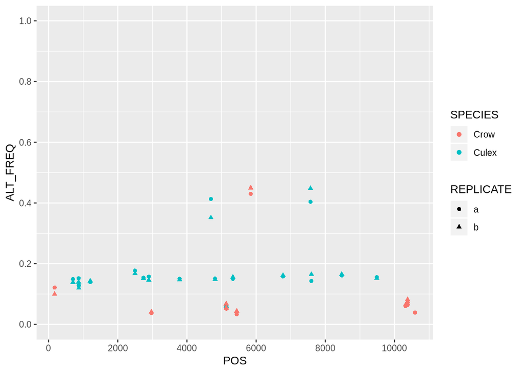

```r
pos_freq.list.a <- get_pos_freq_list_replicate_a(filtered_variants, metadata)
pos_freq.list.b <- get_pos_freq_list_replicate_b(filtered_variants, metadata)

pos_freq <- ldply(pos_freq.list.a)
pos_freq <- rbind(pos_freq, ldply(pos_freq.list.b))

ggplot(pos_freq, aes(x=POS, y=ALT_FREQ, color=SPECIES, shape=REPLICATE)) + geom_point() + scale_x_continuous(breaks = c(0, 2000, 4000, 6000, 8000, 10000)) + scale_y_continuous(limits = c(0, 1), breaks = c(0, 0.2,0.4,0.6,0.8,1))
```

## Invivo samples

```r
invivo_path <- "./masked_variants/invivo"

filtered_variants <- list.files(invivo_path, pattern="*.filtered.tsv", full.names=TRUE)

metadata <- data.frame(
    files <- c("ZI-06", "ZI-07", "ZI-09", "ZI-10", "ZI-11", "ZI-12", "ZI-13", "ZI-15", "ZI-16", "ZI-37", "ZI-48"),
    species <- c("Aedes", "Aedes", "Aedes", "Aedes", "NHP", "NHP", "NHP", "NHP", "NHP", "NHP", "Aedes")
)
colnames(metadata) <- c("file", "species")
metadata$file
```

```
##  [1] ZI-06 ZI-07 ZI-09 ZI-10 ZI-11 ZI-12 ZI-13 ZI-15 ZI-16 ZI-37 ZI-48
## 11 Levels: ZI-06 ZI-07 ZI-09 ZI-10 ZI-11 ZI-12 ZI-13 ZI-15 ZI-16 ... ZI-48
```

```r
metadata$file <- sapply(as.character(metadata$file), function(x){
    paste(x,".masked.filtered.tsv", sep="")
})


## Let's look at the correlation between the iSNVs called form both replicates for all samples
freq.corr <- sapply(filtered_variants, function(x){
    sample <- read.table(x, sep="\t", header=TRUE)
    freq <- cbind(sample[,"POS"], sample[, grepl("ALT_FREQ", colnames(sample))])
    freq.test <- cor.test(freq[,2], freq[,3], method="pearson")
    freq.test$estimate
})

print(freq.corr)
```

```
## ./masked_variants/invivo/ZI-06.masked.filtered.tsv.cor
##                                              0.9922843
## ./masked_variants/invivo/ZI-07.masked.filtered.tsv.cor
##                                              0.9941981
## ./masked_variants/invivo/ZI-09.masked.filtered.tsv.cor
##                                              0.9992304
## ./masked_variants/invivo/ZI-10.masked.filtered.tsv.cor
##                                              0.9919301
## ./masked_variants/invivo/ZI-11.masked.filtered.tsv.cor
##                                              0.9704092
## ./masked_variants/invivo/ZI-12.masked.filtered.tsv.cor
##                                              0.7792300
## ./masked_variants/invivo/ZI-13.masked.filtered.tsv.cor
##                                              0.8208284
## ./masked_variants/invivo/ZI-15.masked.filtered.tsv.cor
##                                              0.9750105
## ./masked_variants/invivo/ZI-16.masked.filtered.tsv.cor
##                                              0.8437387
## ./masked_variants/invivo/ZI-37.masked.filtered.tsv.cor
##                                              0.9887140
## ./masked_variants/invivo/ZI-48.masked.filtered.tsv.cor
##                                              0.9575096
```

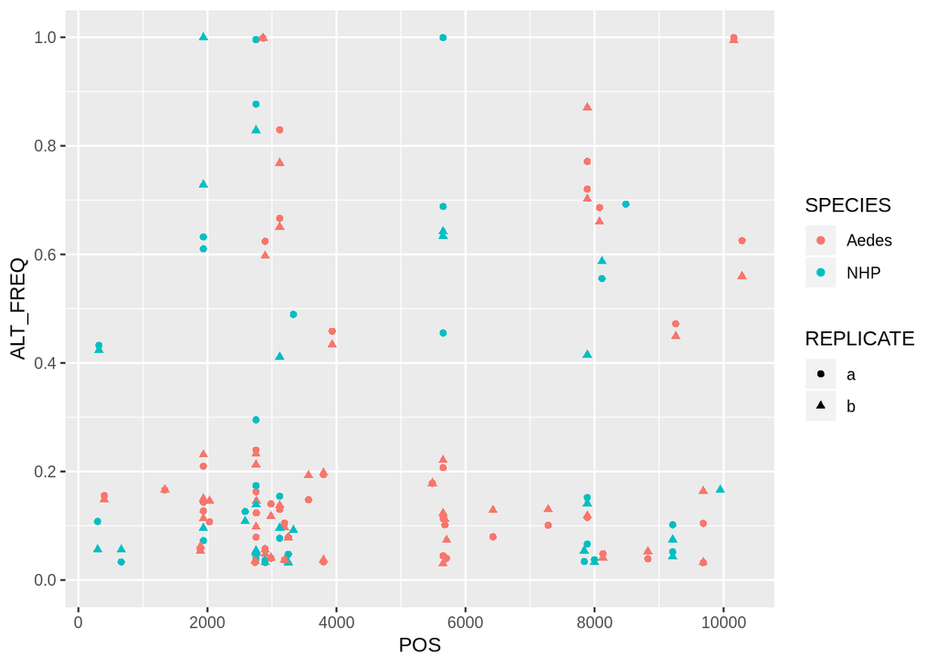

```r
pos_freq.list.a <- get_pos_freq_list_replicate_a(filtered_variants, metadata)
pos_freq.list.b <- get_pos_freq_list_replicate_b(filtered_variants, metadata)

pos_freq <- ldply(pos_freq.list.a)
pos_freq <- rbind(pos_freq, ldply(pos_freq.list.b))

ggplot(pos_freq, aes(x=POS, y=ALT_FREQ, color=SPECIES, shape=REPLICATE)) + geom_point() + scale_x_continuous(breaks = c(0, 2000, 4000, 6000, 8000, 10000)) + scale_y_continuous(limits = c(0, 1), breaks = c(0, 0.2,0.4,0.6,0.8,1))
```

## Invitro samples

```r
invivo_path <- "./masked_variants/invitro"

filtered_variants <- list.files(invivo_path, pattern="*.filtered.tsv", full.names=TRUE)

metadata <- data.frame(
    files <- c("ZI-40", "ZI-41", "ZI-42", "ZI-43", "ZI-44", "ZI-45", "ZI-49", "ZI-50", "ZI-51", "ZI-52", "ZI-53"),
    species <- c("Input", "Aag2", "Aag2", "Aag2", "Aag2", "Aag2", "Hela", "Hela", "Hela", "Hela", "Hela")
)
colnames(metadata) <- c("file", "species")
metadata$file
```

```
##  [1] ZI-40 ZI-41 ZI-42 ZI-43 ZI-44 ZI-45 ZI-49 ZI-50 ZI-51 ZI-52 ZI-53
## 11 Levels: ZI-40 ZI-41 ZI-42 ZI-43 ZI-44 ZI-45 ZI-49 ZI-50 ZI-51 ... ZI-53
```

```r
metadata$file <- sapply(as.character(metadata$file), function(x){
    paste(x,".masked.filtered.tsv", sep="")
})


## Let's look at the correlation between the iSNVs called form both replicates for all samples
freq.corr <- sapply(filtered_variants, function(x){
    sample <- read.table(x, sep="\t", header=TRUE)
    freq <- cbind(sample[,"POS"], sample[, grepl("ALT_FREQ", colnames(sample))])
    freq.test <- cor.test(freq[,2], freq[,3], method="pearson")
    freq.test$estimate
})

print(freq.corr)
```

```
## ./masked_variants/invitro/ZI-40.masked.filtered.tsv.cor
##                                               0.9987326
## ./masked_variants/invitro/ZI-41.masked.filtered.tsv.cor
##                                               0.9916750
## ./masked_variants/invitro/ZI-42.masked.filtered.tsv.cor
##                                               0.9127039
## ./masked_variants/invitro/ZI-43.masked.filtered.tsv.cor
##                                               0.9340806
## ./masked_variants/invitro/ZI-44.masked.filtered.tsv.cor
##                                               0.4962088
## ./masked_variants/invitro/ZI-45.masked.filtered.tsv.cor
##                                               0.3234183
## ./masked_variants/invitro/ZI-49.masked.filtered.tsv.cor
##                                               0.8949094
## ./masked_variants/invitro/ZI-50.masked.filtered.tsv.cor
##                                               0.9779420
## ./masked_variants/invitro/ZI-51.masked.filtered.tsv.cor
##                                               0.9816088
## ./masked_variants/invitro/ZI-52.masked.filtered.tsv.cor
##                                                     NaN
## ./masked_variants/invitro/ZI-53.masked.filtered.tsv.cor
##                                               0.9828178
```

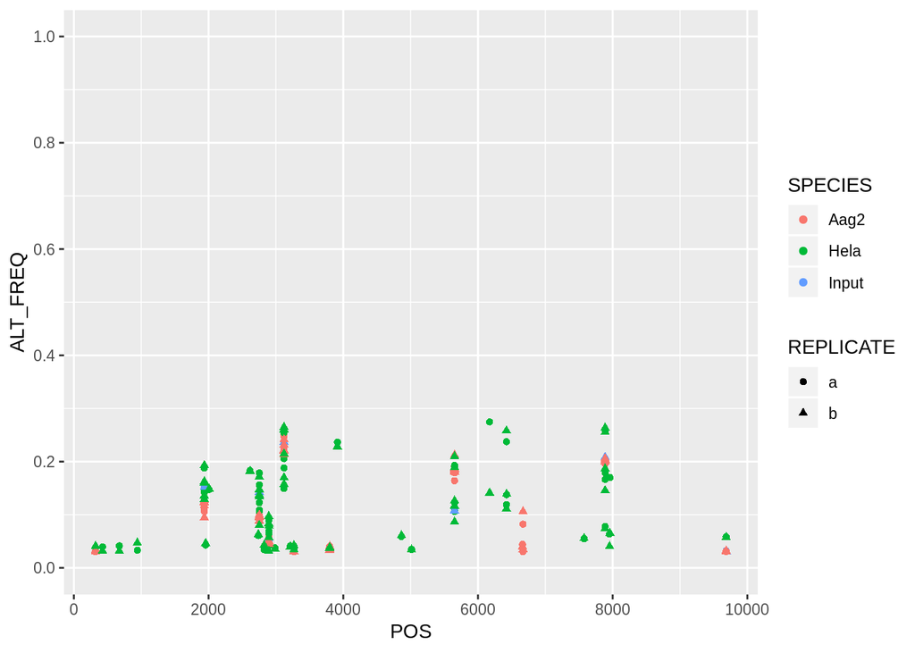

```r
pos_freq.list.a <- get_pos_freq_list_replicate_a(filtered_variants, metadata)
pos_freq.list.b <- get_pos_freq_list_replicate_b(filtered_variants, metadata)

pos_freq <- ldply(pos_freq.list.a)
pos_freq <- rbind(pos_freq, ldply(pos_freq.list.b))

ggplot(pos_freq, aes(x=POS, y=ALT_FREQ, color=SPECIES, shape=REPLICATE)) + geom_point() + scale_x_continuous(breaks = c(0, 2000, 4000, 6000, 8000, 10000)) + scale_y_continuous(limits = c(0, 1), breaks = c(0, 0.2,0.4,0.6,0.8,1))
```